# Capstone Task #3: Exploratory Data Milestone Report

Cory Piette  
May 31, 2020

## Introduction

This project analyzes the [HC Corpora Dataset](https://d396qusza40orc.cloudfront.net/dsscapstone/dataset/Coursera-SwiftKey.zip); Its obective is to create a Shiny App for predicting n-grams. The Task 3 Milestone Report summarizes an exploratory data analysis of various social media platforms.

## File Summary

Three (3) data files from blogs, news sources, and Twitter were uploading into RStudio. The news file dismissed null characters, preventing a full file analysis. The null characters required manual deletion prior to loading the data.

| f_names | f_size | f_lines | n_char | n_words | pct_n_char | pct_lines | pct_words |
| --- | --- | --- | --- | --- | --- | --- | --- |
| blogs | 200.4242 | 899288 | 208361438 | 37334131 | 0.36 | 0.21 | 0.37 |
| news | 196.2775 | 1010242 | 203791400 | 34372528 | 0.35 | 0.24 | 0.34 |
| twitter | 159.3641 | 2360148 | 162385035 | 30373583 | 0.28 | 0.55 | 0.30 |

The associated files are very large, resulting in significant memory usage and a moderate processing speed. In order to expedite the process while maintaining a reasonable data set, ten percent of lines from each file were used in the sample analysis. To further speed processing, we subsetted the n-grams to those that covered 90% of the sample phrases. A fully reproducible version of this data analysis is available at https://github.com/coryjpiette/Capstone/blob/master/Task2Exp.md

## Uni-grams

The corpora are referenced by abbreviations and acronyms that reflect today’s social conventions for online conversations - such as “lol” for “laugh out loud” - as well as short-hand (albeit incorrect) word usage such as “dont” for “don’t” or “do not.” These remained as uni-grams.

### Uni-gram Wordcloud

Distribution can be summarized with a word cloud, an application that utilizes font size and color to rank frequency. The words, “im”, and “time” show up as most frequent followed by “people”, “dont”, “day”, and “love”. While this is a popular method, shown below is the anaylsis represented as a frequency columnn.

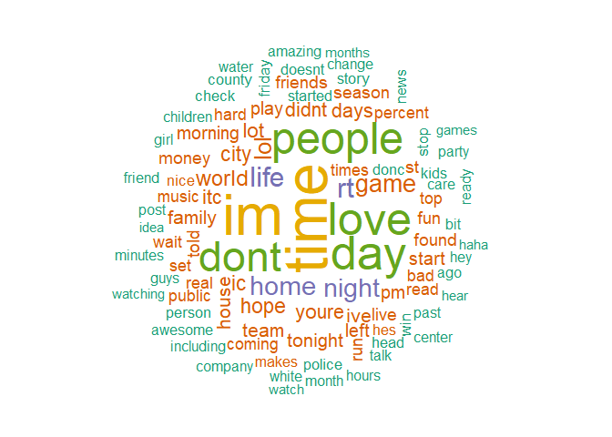

### Uni-grms, By Source

All three files displayed different word relative frequencie. Examples: “rt” occurs only on twitter, “ic” and “donc” only in blogs, and “city”, “percent”, “county” only in news.

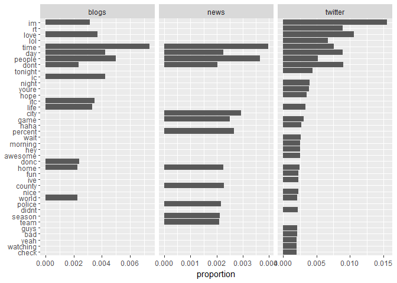

## Uni-gram Distribution

Distributions were created for each set of n-grams, based on relative frequency.

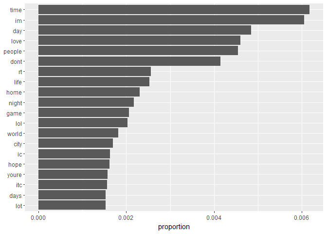

## Bi-gram Distribution

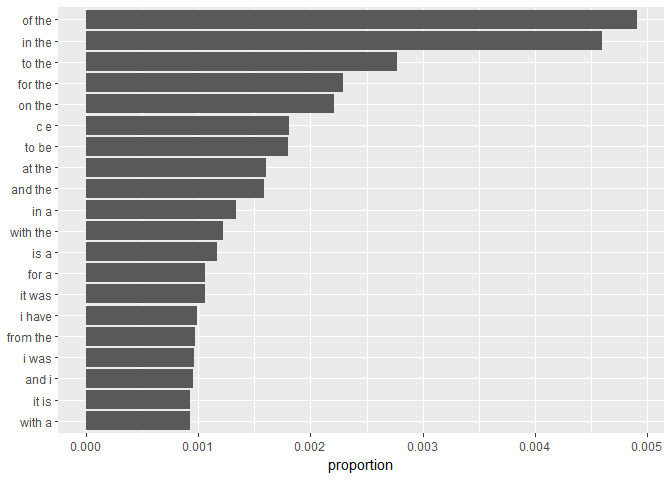

## Tri-gram Distribution

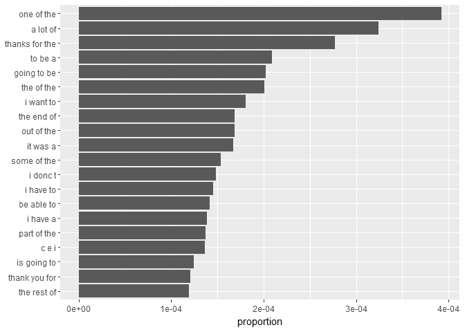

## Quad-gram Distribution

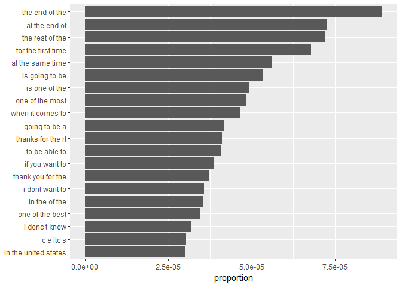

## N-gram Prediction Model

I expect to use the n-gram tables created for bi-gram, tri-grams, and quad-grams as the basis for prediction. The user will input a word, the model will find the bi-gram with the greatest relative frequency given that word. Similarly, the tri-gram table will be used for making predictions from two word entries and so on.

[output not shown]

Notable is that, in the quad-gram table, 4-grams are separated by word and arranged by relative frequency. When the user inputs three words, the model matches those words and then finds the fourth word with the greatest relative frequency. Cases where there is no match, or where more than three words are entered, the result will be random.